# Visualize Data: The Basics

## 2.6 Global versus Local

What if you have several layers you want to apply in a plot and they all use the same basic aesthetics (e.g. x, y, etc)? It would be quite time consuming to write all of those out in each geom_ function argument. Therefore, you can apply some of them globally to all layers by including them in the `ggplot()` code. Then, mappings applied in specific geom_ functions will add or override the global mappings for that layer only.

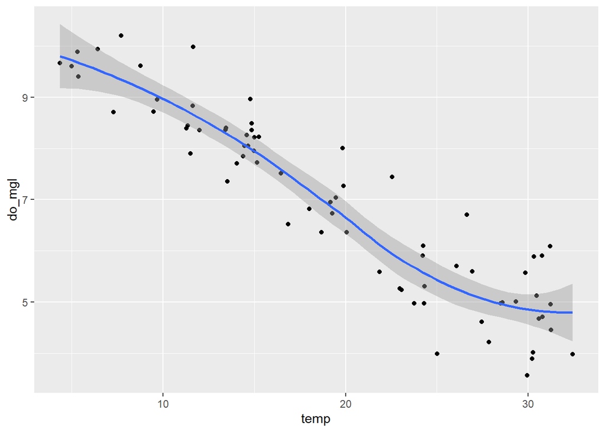

```r
ggplot(data = wq, mapping = aes(x = temp, y = do_mgl)) +
    geom_point() +
    geom_smooth()
```

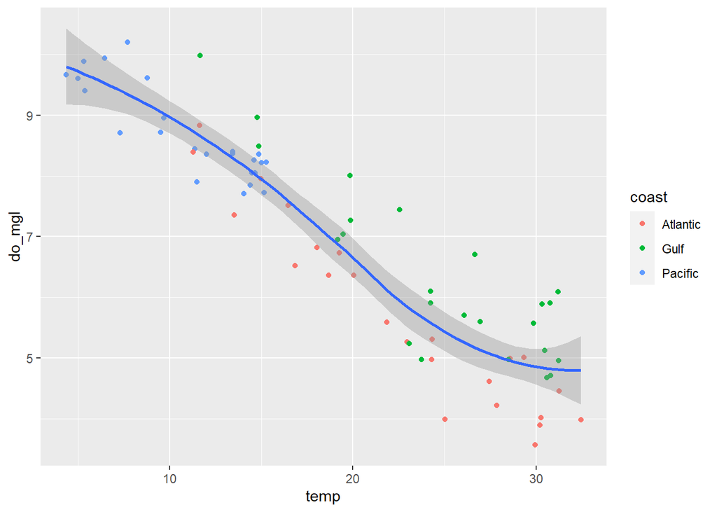

```r
ggplot(data = wq, mapping = aes(x = temp, y = do_mgl)) +
    geom_point(mapping = aes(color = coast)) +
    geom_smooth()
```

Notice how only color is applied to the points in the figure, not anywhere else. That is because color was only an aesthetic that was applied in the geom_point layer.

# 3 Part 1 Recap:

To make a graph:

1. Pick your *data* set
2. Choose the best *geom* to display the cases
3. *Map* aesthetic properties to variables.
4. **Not required**, but defaults are supplied by the specified geom that you can then manually change.

```r
ggplot(data = <DATA>) +
    <GEOM FUNCTION>(mapping = aes(<MAPPINGS>),
                   stat = <STAT>, # not required, but sensible default applied.
                   position = <POSITION>) # not required, but sensible default applied.
```

# 4 The Basics Part 2

What else can you do?

- Scales
- Coordinate Systems
- Themes
- Saving your plots

## 4.1 Scales

*Scales* control the way your data is mapped to your geom and are required by every aesthetic. Again, `ggplot2` selects sensible defaults, but you can provide further adjustments.

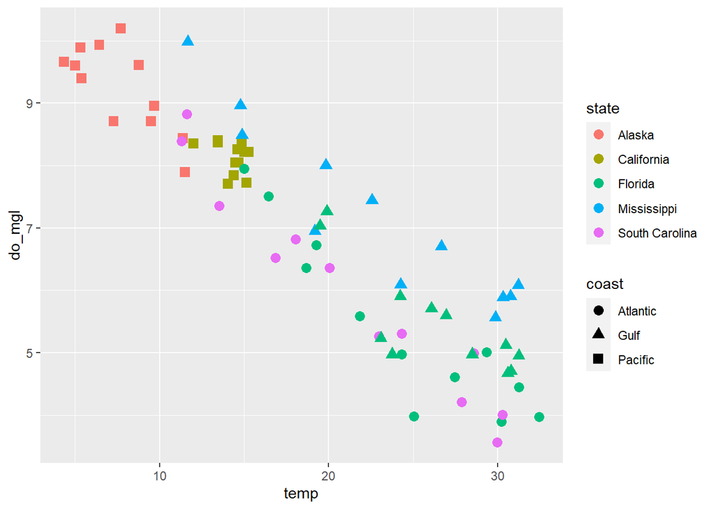

```r
ggplot(wq, aes(x = temp, y = do_mgl)) +
  geom_point(aes(shape = coast, color = state), size = 3)
```

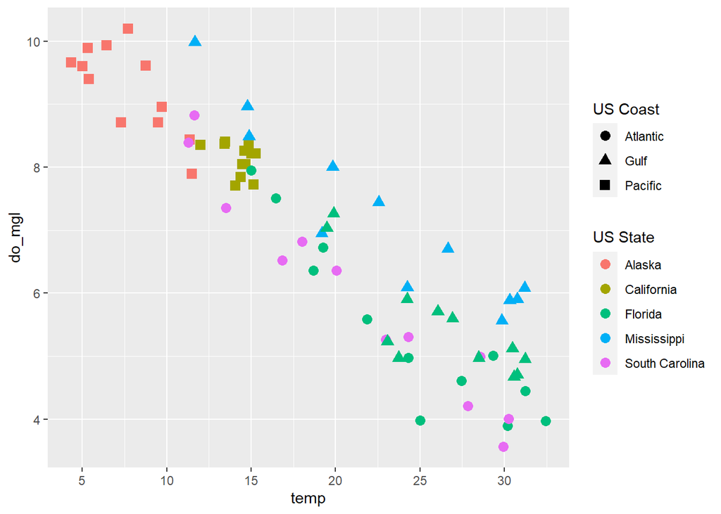

```r
ggplot(wq, aes(x = temp, y = do_mgl)) +
  geom_point(aes(shape = coast, color = state), size = 3) +
  scale_shape_discrete(name = "US Coast") + # renamed scale for the shape aesthetic, applies to legend
  scale_color_discrete(name = "US State") + # renamed scale for the color aesthetic, applies to legend
  scale_y_continuous(breaks = c(2, 4, 6, 8, 10)) + # adjusted the axis breaks in the y axis scale
  scale_x_continuous(breaks = c(5, 10, 15, 20, 25, 30, 35)) # adjusted the axis breaks in the x axis scale
```

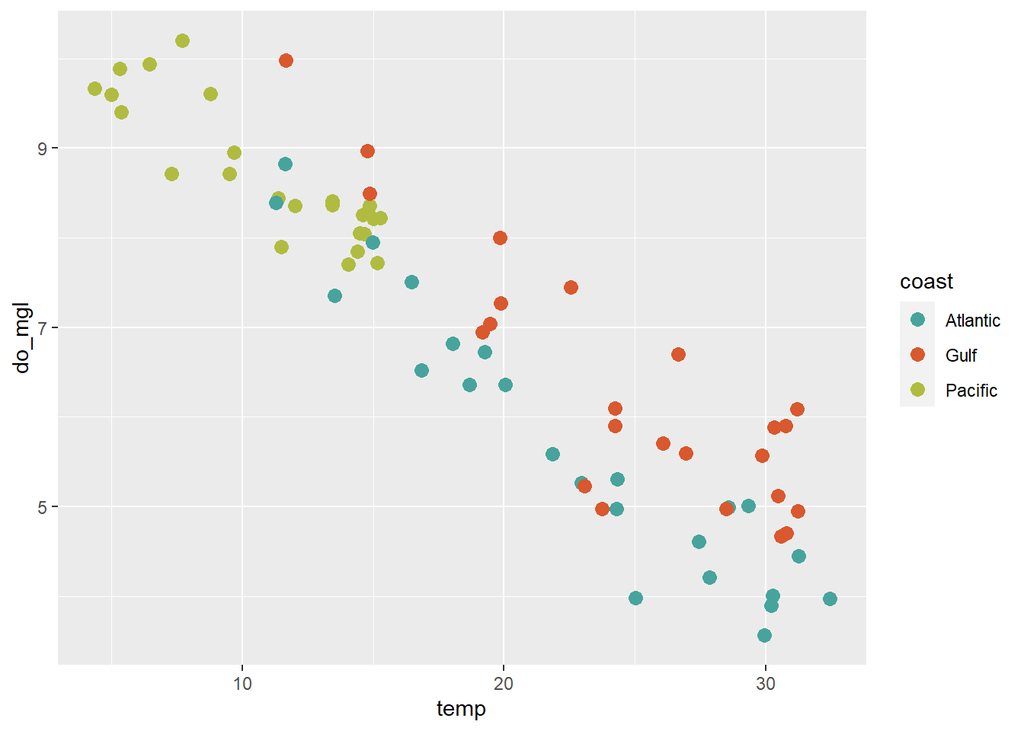

```r
# manual
ggplot(wq, aes(x = temp, y = do_mgl)) +
  geom_point(aes(color = coast), size = 3) +
  scale_color_manual(labels = c('Atlantic', 'Gulf', 'Pacific'),
                     values = c('#47A49D', '#D9582E', '#B0BC40'))
```

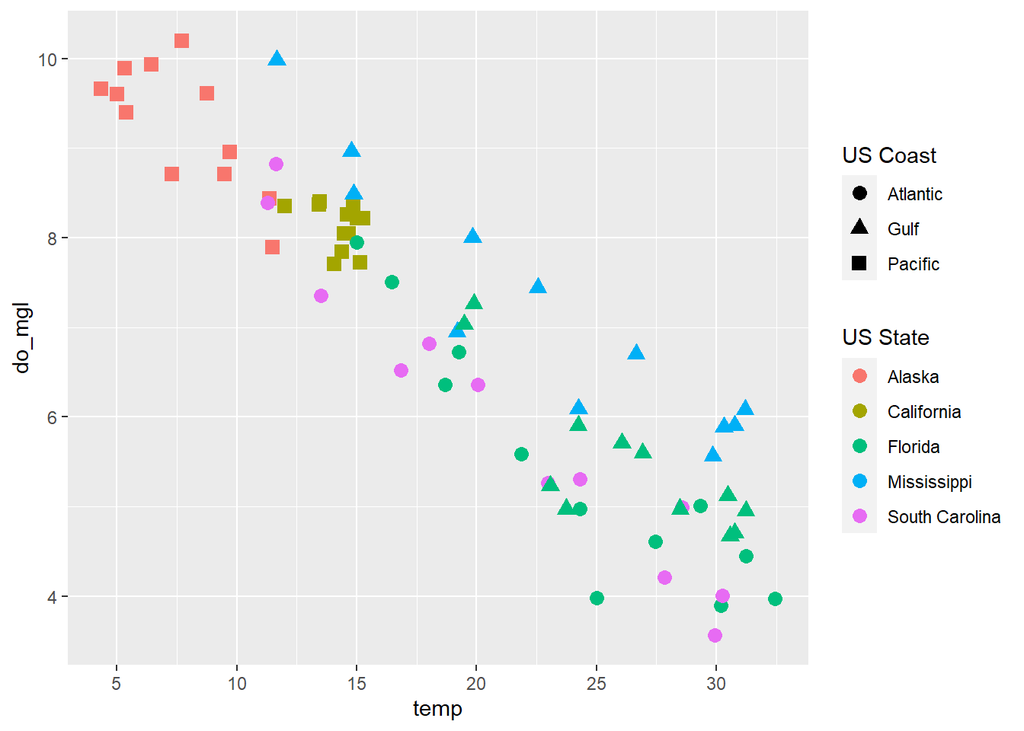

```r
# New update to changing legend names
ggplot(wq, aes(x = temp, y = do_mgl)) +
  geom_point(aes(shape = coast, color = state), size = 3) +
  scale_y_continuous(breaks = c(2, 4, 6, 8, 10)) +
  scale_x_continuous(breaks = c(5, 10, 15, 20, 25, 30, 35)) +
  labs(color = "US State", # add aesthetic into the labs() argument!
       shape = "US Coast")
```